# Processing Textual Data in R

# Introduction

Welcome to the first practical of the course “Introduction to Text Mining with R”.

In the practicals we will get hands-on experience with the materials in the lectures by programming in R and completing assignments. In this practical, we will work with different formats of text data, regular expressions and some visualisations.

The practicals always start with the packages we are going to use. Be sure to run these lines in your session to load their functions before you continue. If there are packages that you have not yet installed, first install them with `install.packages()`.

```r
library(dplyr)     # for data manipulation
library(plyr)      # for data manipulation
library(magrittr)  # for pipes
library(tidyverse) # for tidy data and pipes
library(ggplot2)   # for visualization
library(xlsx)      # for working with excel files
library(qdap)      # provides parsing tools for preparing transcript data
library(wordcloud) # to create pretty word clouds
```

Before starting the exercises, you need to set your working directory to your Practicals folder. To this end, you can either create a project in RStudio and move the Rmd and data files to the project forlder, or you can use the following line instead of creating a new project:

```r
# setwd("drivename:/folder1/folder2/r_tm/monday/Practicals/")
```

# Reading text data: Excel files

1. **Use the `read.xlsx` function from the `xlsx` package to read the `blog-gender-dataset.xlsx` file:**

The dataset is already located in the practical folder. You can also find it online from [here](https://www.cs.uic.edu/~liub/FBS/sentiment-analysis.html#datasets)

```r
blog_gender_data <- read.xlsx("blog-gender-dataset.xlsx", 1)
```

2. **Randomly sample 1000 of the blogs into a new variable and name it `blog_gender_1000`. Hint: use the `sample_n` function.**

It is good to know that, to learn more about the contents of a function, data or variable, use one of the two following help commands:

```r
help(your_function_name)
```

```
## No documentation for 'your_function_name' in specified packages and libraries:
## you could try '??your_function_name'
```

```r
?your_function_name
```

```
## No documentation for 'your_function_name' in specified packages and libraries:
## you could try '??your_function_name'
```

```r
blog_gender_1000 <- sample_n(blog_gender_data, 1000)
```

3. **Use the `head`, `tail`, and `View` functions to check the dataset. What are the differences between these functions?**

```r
head(blog_gender_1000)
```

|  | blog | gender | NA. | NA..1 | NA..2 | NA..3 |
| --- | --- | --- | --- | --- | --- | --- |
| 1 | Nonprofit organizationsâ\200”and their staff/boardsâ\200”which are part of the institutional Catholic Church should clearly support the teachings of the Church, just as employees/board members of any … | M | NA | NA | NA | NA |
| 2 | So I had another odd dream.....\n\nI enter some unknown town and am waiting in line with my mom. This kid says to me "what are you doing here?" Then I look up and my brother also says "aren't you bann… | F | NA | NA | NA | NA |
| 3 | It makes me uncomfortable when people talk across cubicles in restrooms. I don't know if men do this as well. I know some women at my office who are "restroom buddies". They enter the restrooms chatti… | F | NA | NA | NA | NA |
| 4 | You hear many vhristians claiming that their god is the absence of evil. They usually start their conversation with things like "dark is the absence of light" and "heat is the absence of cold". There … | M | NA | NA | NA | NA |
| 5 | So I was in charge of preschool yesterday and I think it went well. My topic was fire safety. First I had a candle burning and I showed them (from a safe distance) what fire looks like. Then I blew it… | F | NA | NA | NA | NA |
| 6 | big piles of each color right on the carpet, and even made a mixing pile of purple. Little Picasso had made such a mess!I grabbed towels, a bucket of water and every bottle of stain remover I could fi… | F | NA | NA | NA | NA |

```r
tail(blog_gender_1000)
```

|  | blog | gender | NA. | NA..1 | NA..2 | NA..3 |
| --- | --- | --- | --- | --- | --- | --- |
| 995 | Last Saturday we went to a so called Gypsy Fair, which was more market for weird stuff then actual fair. But the â\200œhouse trucksâ\200\235 were interesting to look at. If you imagine an old gypsy wa… | F | NA | NA | NA | NA |
| 996 | There are many things in life that make me happy. Little things, things that just make me smile. One of my favorites is Post Secret Sundays. Post Secret is a project started a few years ago by a man n… | F | NA | NA | NA | NA |
| 997 | I own a 9 1/2 year old German Shepherd mix. We believe his father was a black lab with chow mix. His mother was a full-blooded German Shepherd.Fred is a great dog. He weighs 110 lbs. so you can't ever… | F | NA | NA | NA | NA |
| 998 | What?!?! MORE cupcakes? Where are the drawings and sewings and art, Alicia?' you say.'Psshaw!' say I. ' I HAD to make them! They're brain slugs. I have no choice.'And so this past weekend, I made some… | F | NA | NA | NA | NA |
| 999 | Luxury SUVs have become such a common sight that the notation for the 2010 Acura MDX on our schedule didn't raise much interest around the office. But then we saw the thing. Rather than the somewhat d… | M | NA | NA | NA | NA |
| 1000 | I recently saw a krafts cheese add on TV. The commercial talks about how great kraft's is and towards the end it say's "A country is only as good as it's cheese, and Ours (kraft's cheese) doesn't have… | M | NA | NA | NA | NA |

```r
# View(blog_gender_1000)
```

The `%$%` pipe *exposes* the listed dimensions of a dataset, such that we can refer to them directly.

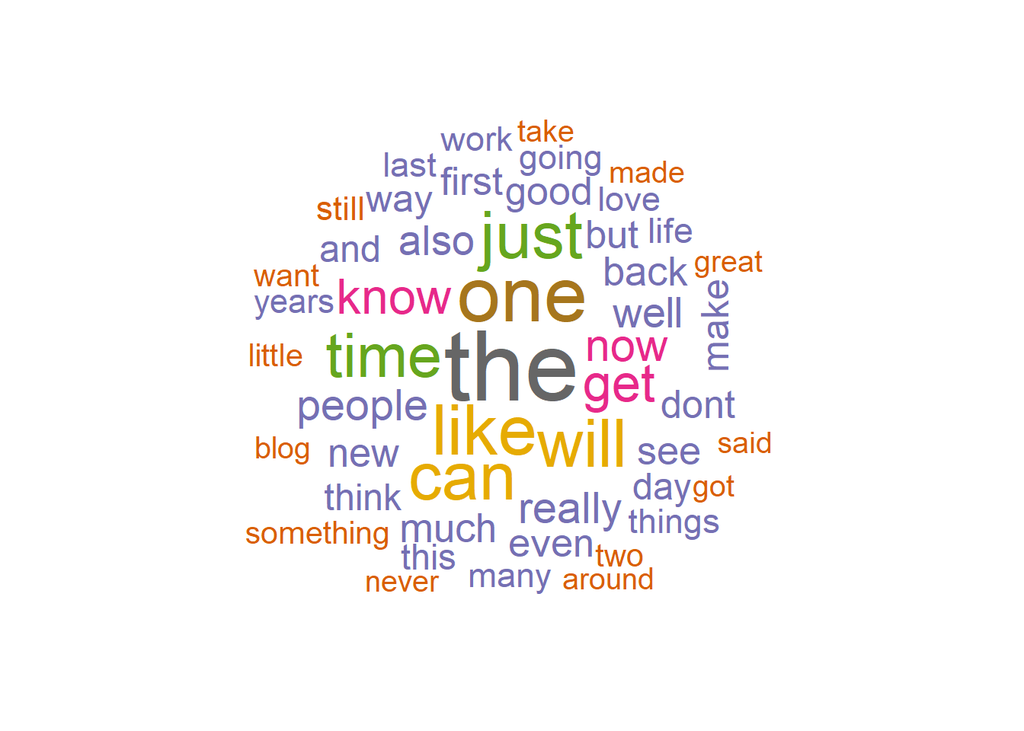

```r
blog_gender_1000 %$% wordcloud(blog, min.freq = 20, max.words = 50, random.order = FALSE,
                               colors = brewer.pal(8, "Dark2"))
```

# Reading text data: CSV files

5. **Use the `read.csv` function to read the `IMDB Dataset.csv` file:**

IMDB dataset contains 50K movie reviews for natural language processing or Text analytics. You can also access the dataset from the [Kaggle website](https://www.kaggle.com/lakshmi25npathi/imdb-dataset-of-50k-movie-reviews).

```r
imdb_data <- read.csv("IMDB Dataset.csv")
```

6. **Use the `head` and `tail` functions to take a look at the dataset.**

```r
head(blog_gender_1000)
```

[output not shown]

```r
tail(blog_gender_1000)
```

[output not shown]

7. **Randomly sample 500 of the reviews into a new variable and name it `imdb_500`. In your sample take care of having equal number of observations from positive and negative reviews. (250 each)**

```r
imdb_500 <- ddply(imdb_data, "sentiment", .fun = function(x) {sample_n(x, size = 250)})
```

8. **Plot the word coulds of positive and negative reviews in your sample separately and compare the visualizations.**

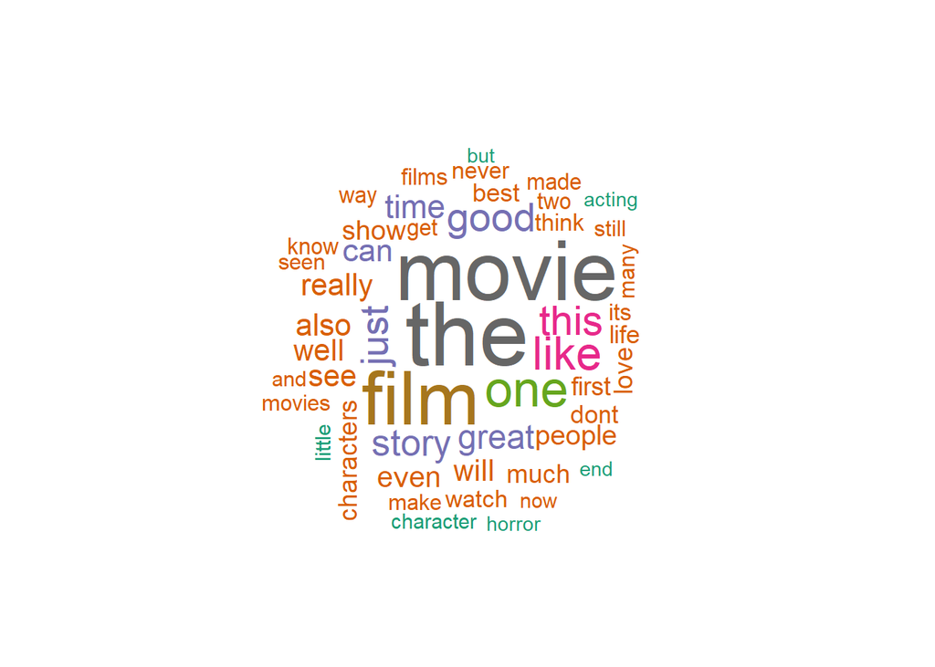

```r
imdb_500 %>%
  filter(sentiment == "positive") %$%
  wordcloud(review, min.freq = 20,
                       max.words = 50, random.order = FALSE,
                       colors = brewer.pal(8, "Dark2"))
```

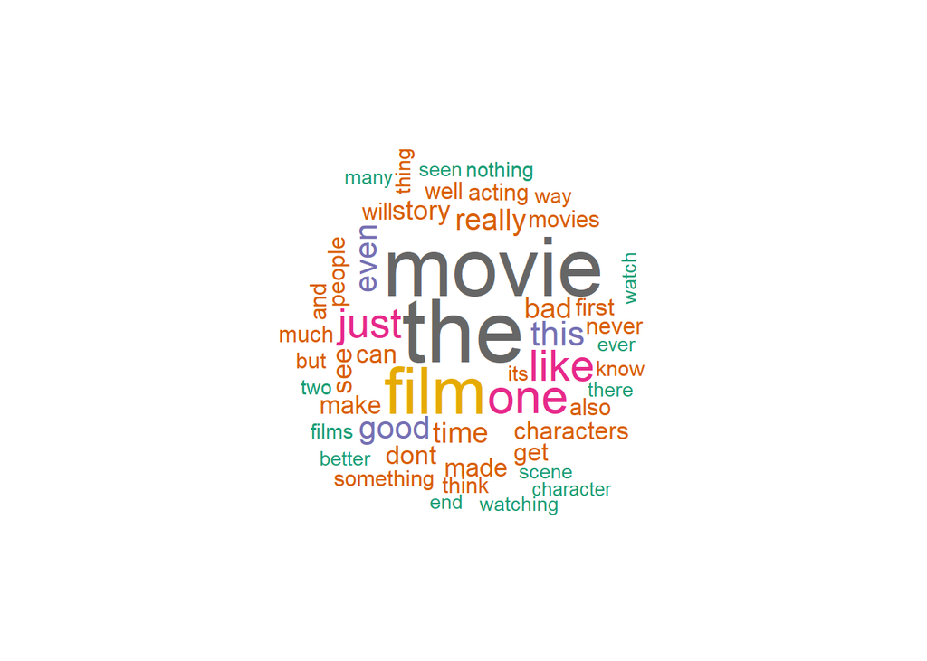

```r
imdb_500 %>%
  filter(sentiment == "negative") %$%
  wordcloud(review, min.freq = 20,
                       max.words = 50, random.order = FALSE,
                       colors = brewer.pal(8, "Dark2"))
```

9. **Use the `freq_terms` function from the `qdap` package and find the 30 top terms in each set of positive and negative reviews in `imdb_500`.**

```r
frequent_terms_pos <- imdb_500 %>%
  filter(sentiment == "positive") %$%
  freq_terms(review, top = 30)

frequent_terms_neg <- imdb_500 %>%
  filter(sentiment == "negative") %$%
  freq_terms(review, top = 30)
```

10. **Using `ggplot`, plot a barchart for each of the freqent terms dataframes.**

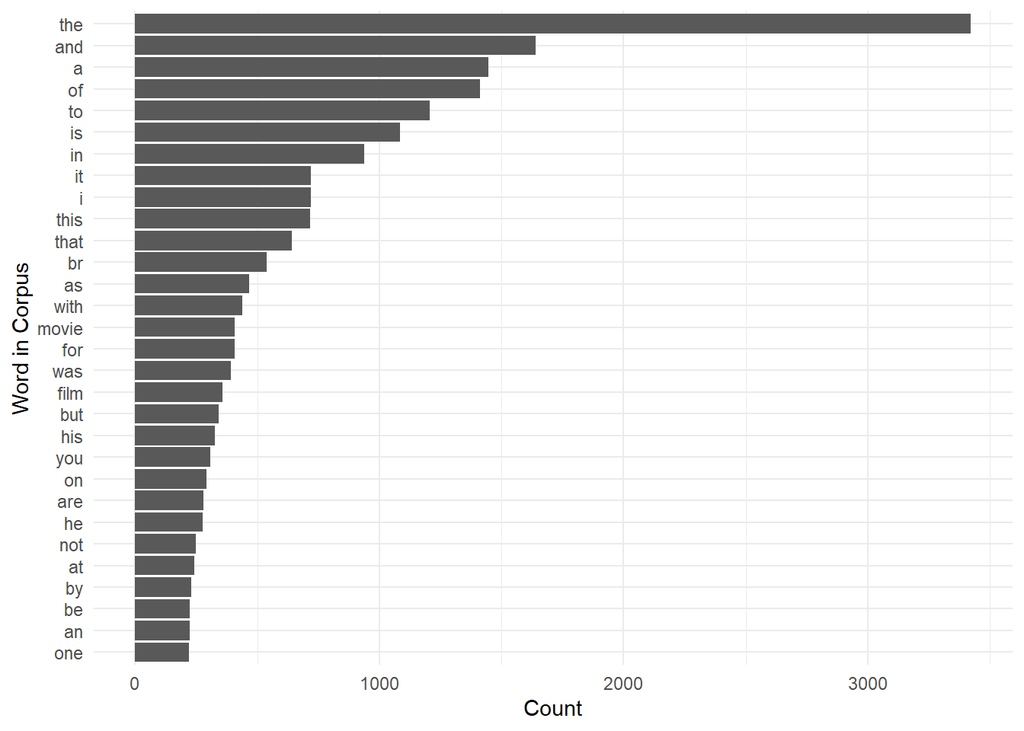

```r
ggplot(frequent_terms_pos, aes(x = reorder(WORD, FREQ), y = FREQ)) +
geom_bar(stat = "identity") +
coord_flip()                +
xlab("Word in Corpus")      +
ylab("Count")               +
theme_minimal()
```

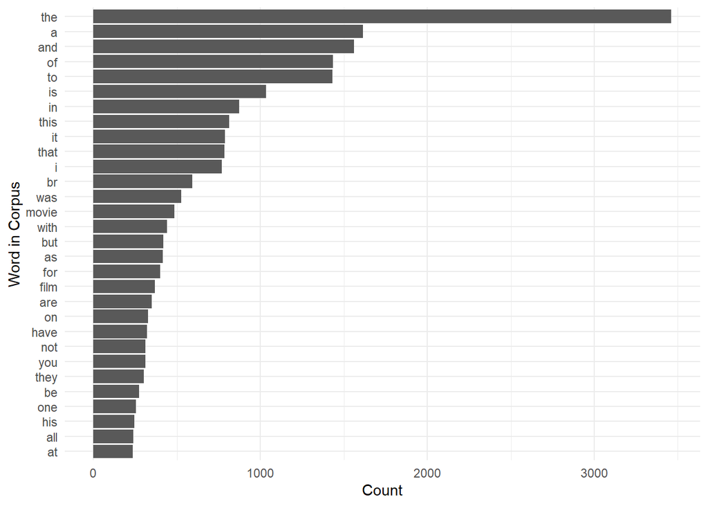

```r
ggplot(frequent_terms_neg, aes(x = reorder(WORD, FREQ), y = FREQ)) +
geom_bar(stat = "identity") +
coord_flip()                +
xlab("Word in Corpus")      +
ylab("Count")               +
theme_minimal()
```

Package `ggplot2` offers far greater flexibility in data visualization than the standard plotting devices in `R`. However, it has its own language, which allows you to easily expand graphs with additional commands. To make these expansions or layers clearly visible, it is advisable to use the plotting language conventions. All ggplot2 documentation can be found at http://docs.ggplot2.org/current/

# Reading text data: TXT files

11. **Use the `readLines` function to read data from the ‘computer.txt’ file.**

`Computer.txt` is an annotated dataset for the purpose of aspect-based sentiment analysis. You can find it from [here](https://www.cs.uic.edu/~liub/FBS/sentiment-analysis.html).

```r
computer_data <- readLines("computer.txt")
```

12. **Convert the data to a dataframe.**

```r
computer_531 <- data.frame(computer_data)
```

As you may have noticed, here, we worked only with dataframes. In addition to dataframes we will also use `VCorpus` data type.

13. **Use the `head` and `tail` functions to take a look at the dataset.**

```r
head(computer_531)
```

|  | computer_data |
| --- | --- |
| 1 | ## I purchased this monitor because of budgetary concerns . |
| 2 | inexpensive[+1][a] ## This item was the most inexpensive 17 inch monitor available to me at the time I made the purchase . |
| 3 | monitor[-1] ## My overall experience with this monitor was very poor . |
| 4 | screen[-1], picture quality[-1] ## When the screen was n't contracting or glitching the overall picture quality was poor to fair . |
| 5 | monitor[-1], picture quality[-1] ## I 've viewed numerous different monitor models since I 'm a college student and this particular monitor had as poor of picture quality as any I 've seen . |
| 6 | screen[-1] ## A week out of the box and I began to see slight contractions of the screen from time to time , growing more frequent each day . |

```r
tail(computer_531)
```

|  | computer_data |
| --- | --- |
| 526 | ## Eventually , I discovered that something was wrong with my display drivers and I simply wiped out windows and started over from scratch -LRB- had been meaning to do it anyway and I upgraded the HD … |
| 527 | ## After that , it worked like a champ . |
| 528 | ## No problems whatsoever . |
| 529 | incompatibility[-1] ## My only grips are the incompatibility with XP and the USB hub in the display . |
| 530 | ## This is a well know problem with the PCs and Apple does not seem to care . |
| 531 | ## Also , the only hard button controls you get are brightness and contrast . |

# Regular expressions

16. **Except `computer_531`, `imdb_500`, and `blog_gender_1000` remove the other files from the RStudio environment**

```r
# using regular expressions
rm(list = ls()[grep("data", ls())])
rm(list = ls()[grep("^fre", ls())])

# or
# rm(blog_gender_data, computer_data, frequent_terms_pos, frequent_terms_neg, imdb_data)

# or use except files
# rm(list=setdiff(ls(), c("computer_531", "imdb_500", "blog_gender_1000")))
```

17. **Use regular expressions to find the number of reviews in `imdb_500` that contain words “Action”, “Comedy”, “Drama”. Also include the lower case of the words in your seach.**

```r
reviews_act <- grep("[Aa]ction", imdb_500$review)
reviews_com <- grep("[Cc]omedy", imdb_500$review)
reviews_dra <- grep("[Dd]rama", imdb_500$review)

genres    <- c("Action", "Comedy", "Drama")
nr_genres <- c(length(reviews_act), length(reviews_com), length(reviews_dra))

tibble(genres, nr_genres)
```

| genres | nr_genres |
| --- | --- |
| Action | 54 |
| Comedy | 40 |
| Drama | 45 |

```r
grep("Comedy", imdb_500$review, value = TRUE)
```

```
## [1] "\"Mad Dog Time\"...\"Trigger Happy\" whatever you wanna call it...simply doesn't hit the mark. Maybe its just me, maybe i just don't like Gangster comedies ( as i thought Oscar , Johney Dangerously and Mafia also sucked ) It's probably more \"witty sharp wordplay\" than all out Comedy, only …
## [2] "Well, this might be one of the funniest movies of all time, and Sandy gives a tour-de-force performance! Alas, her career never quite took off, but - at last - she will always be remembered for her three first-rate pictures: \"The King Of Comedy\", \"Dallas Doll\", and \"Without You I'm Noth…
## [3] "The first time I saw \"Alice in Wonderland Â– an X-rated Musical Comedy\", was in the early '80 in a Movie-Theater in N.Y. City with some friends. I remember we actually enjoyed it very much, although we were left wondering why all the \"goodies\" were covered by in various forms shaped colo…
## [4] "\"Tipping The Velvet\" is one of the modern day television productions that prove that some television can be just as good or even better(as this is) than what you see at your local theater. <br /><br />If you want to read the plot, read this and if you want other details skip down to the ne…
## [5] "I also attended the RI International Horror Film Festival and I can easily see why this film won best of show.<br /><br />SEA OF DUST is a wild romp of Horror, Comedy and beautiful scenery. A back in time tale of strange goings on. An increasingly wide spread illness with an overwhelmingly i…
```

```r
# you can also use the returned index instead of setting value
```

`grep()` and the `grepl()` functions have some limitations. These functions tell you which strings in a character vector match a certain pattern but they don’t tell you where exactly the match occurs or what the match is for a more complicated regular expression.

19. **Use the `regexpr` function to check if there is a fully campitalized word in each of the first 20 blogs in the `blog_gender_1000` data.**

```r
r <- regexpr('\\b[A-Z]+\\b', blog_gender_1000[1:20,]$blog)
r
```

```
##  [1] 1096    4   74  581    4  121    1   42   76   21    1   17    1    1    3
## [16]  504  371   -1  244    6
## attr(,"match.length")
##  [1]  1  1  1  1  1  1  1  1  1  2  1  3  1  1  1  3  1 -1  4  1
```

```r
regmatches(blog_gender_1000[1:20,]$blog, r)
```

```
##  [1] "D"    "I"    "I"    "I"    "I"    "I"    "I"    "I"    "I"    "RX"
## [11] "I"    "API"  "I"    "A"    "I"    "DIY"  "A"    "DADA" "I"
```

The regexpr() function gives you the (a) index into each string where the match begins and the (b) length of the match for that string.

The `str_extract` function from `stringr` is also a useful function for this purpose:

```r
str_extract(blog_gender_1000[1:20,]$blog, '\\b[A-Z]+\\b')
```

```
##  [1] "D"    "I"    "I"    "I"    "I"    "I"    "I"    "I"    "I"    "RX"
## [11] "I"    "API"  "I"    "A"    "I"    "DIY"  "A"    NA     "DADA" "I"
```

20. **`regexpr` and `str_extract` only give you the first match of the string (reading left to right). On the other hand, `gregexpr` and `str_match_all` will give you all of the matches in a given string if there are is more than one match. Use either of thesse functions to check if there is fully campitalized words in each of the first 10 blogs in the `blog_gender_1000` data.**

```r
r <- gregexpr('\\b[A-Z]+\\b', blog_gender_1000[1:10,]$blog)
regmatches(blog_gender_1000[1:10,]$blog, r)
```

```
## [[1]]
##  [1] "D"    "C"    "A"    "D"    "C"    "A"    "E"    "A"    "A"    "A"
## [11] "I"    "H"    "C"    "D"    "OMB"  "ARR"  "ARR"  "U"    "S"    "PIRG"
## [21] "VPP"  "I"    "I"    "I"    "I"    "I"    "I"    "I"    "HOW"  "WHY"
## [31] "WHAT" "I"    "I"    "I"    "A"
##
## [[2]]
##  [1] "I" "I" "I" "I" "I" "I" "I" "I" "I" "I" "I" "I"
##
## [[3]]
## [1] "I" "I"
##
## [[4]]
## [1] "I" "A"
##
## [[5]]
## [1] "I" "I" "I" "I" "I" "I"
##
## [[6]]
##  [1] "I"   "I"   "NOT" "I"   "I"   "I"   "I"   "I"   "AND" "I"   "I"   "I"
## [13] "I"   "I"   "I"   "I"   "I"
##
## [[7]]
## [1] "I" "I" "I" "I" "I" "I"
##
## [[8]]
##  [1] "I"       "I"       "I"       "NEWS"    "ITEM"    "DC"      "EEEK"
##  [8] "HOM"     "EEEK"    "HERE"    "I"       "THOIA"   "NEWS"    "FLASH"
## [15] "FINALLY" "THOIA"   "A"       "I"       "THOIA"   "I"       "A"
## [22] "PLUS"    "THOIA"   "I"       "THOIA"   "I"       "A"       "NEXT"
## [29] "THOIA"   "A"       "I"
##
## [[9]]
##  [1] "I"  "I"  "I"  "I"  "I"  "R"  "R"  "TV" "I"  "I"  "I"  "I"  "I"  "I"  "I"
## [16] "I"  "I"
##
## [[10]]
## [1] "RX" "RX" "I"  "I"  "I"
```

```r
str_match_all(blog_gender_1000[1:10,]$blog, '\\b[A-Z]+\\b')
```

[output not shown]

[output cut: 142 more lines]

21. **Now we want to process the `computer_531` data and separate aspects and sentiments for each record. First, use regular expression to extract the characters at the beginging of each line until `##`. Apply this only for the first 20 reviews in data. Use `str_extract` or `gsub` function.**

```r
str_extract(computer_531[1:20,], "[^##]*")
```

```
##  [1] ""                                  "inexpensive[+1][a] "
##  [3] "monitor[-1] "                      "screen[-1], picture quality[-1] "
##  [5] "monitor[-1], picture quality[-1] " "screen[-1] "
##  [7] "Display[-1] "                      "monitor[-1] "
##  [9] ""                                  ""
## [11] ""                                  ""
## [13] ""                                  "monitor[-1], colors[-1] "
## [15] ""                                  "size[+1] "
## [17] "computer[+1], quality[+1] "        ""
## [19] "keyboard[+1], color[+1] "          "speed[+1], memory[+1] "
```

```r
# gsub("[^##]*", "\\1", computer_531[1:20,])
gsub("(.?)(##.*)", "\\1", computer_531[1:20,])
```

```
##  [1] ""                                  "inexpensive[+1][a] "
##  [3] "monitor[-1] "                      "screen[-1], picture quality[-1] "
##  [5] "monitor[-1], picture quality[-1] " "screen[-1] "
##  [7] "Display[-1] "                      "monitor[-1] "
##  [9] ""                                  ""
## [11] ""                                  ""
## [13] ""                                  "monitor[-1], colors[-1] "
## [15] ""                                  "size[+1] "
## [17] "computer[+1], quality[+1] "        ""
## [19] "keyboard[+1], color[+1] "          "speed[+1], memory[+1] "
```

22. **Add a new column to `computer_531` and name it aspect_sentiment. Fill this column for the entire data with the command you found in the previous question.**

```r
computer_531$aspect_sentiment <- gsub("(.?)(##.*)", "\\1", computer_531[,])
head(computer_531)
```

|  | computer_data | aspect_sentiment |
| --- | --- | --- |
| 1 | ## I purchased this monitor because of budgetary concerns . |  |
| 2 | inexpensive[+1][a] ## This item was the most inexpensive 17 inch monitor available to me at the time I made the purchase . | inexpensive[+1][a] |
| 3 | monitor[-1] ## My overall experience with this monitor was very poor . | monitor[-1] |
| 4 | screen[-1], picture quality[-1] ## When the screen was n't contracting or glitching the overall picture quality was poor to fair . | screen[-1], picture quality[-1] |
| 5 | monitor[-1], picture quality[-1] ## I 've viewed numerous different monitor models since I 'm a college student and this particular monitor had as poor of picture quality as any I 've seen . | monitor[-1], picture quality[-1] |
| 6 | screen[-1] ## A week out of the box and I began to see slight contractions of the screen from time to time , growing more frequent each day . | screen[-1] |

23. **Now remove the sentiment scores from aspects. Add the only-aspect to another column to `computer_531` and name it `aspects`.**

```r
computer_531$aspects  <- gsub("\\[.+?\\]", "", computer_531$aspect_sentiment)
head(computer_531)
```

|  | computer_data | aspect_sentiment | aspects |
| --- | --- | --- | --- |
| 1 | ## I purchased this monitor because of budgetary concerns . |  |  |
| 2 | inexpensive[+1][a] ## This item was the most inexpensive 17 inch monitor available to me at the time I made the purchase . | inexpensive[+1][a] | inexpensive |
| 3 | monitor[-1] ## My overall experience with this monitor was very poor . | monitor[-1] | monitor |
| 4 | screen[-1], picture quality[-1] ## When the screen was n't contracting or glitching the overall picture quality was poor to fair . | screen[-1], picture quality[-1] | screen, picture quality |
| 5 | monitor[-1], picture quality[-1] ## I 've viewed numerous different monitor models since I 'm a college student and this particular monitor had as poor of picture quality as any I 've seen . | monitor[-1], picture quality[-1] | monitor, picture quality |
| 6 | screen[-1] ## A week out of the box and I began to see slight contractions of the screen from time to time , growing more frequent each day . | screen[-1] | screen |

```r
# computer_531 <- computer_531 %>%
#  mutate(aspects = gsub("\\[.+?\\]", "", computer_531$aspect_sentiment))


# only for +1 and -1
# gsub("\\[(.+?)1\\]", "", "a yes[+1][a]")
# gsub("\\[(\\+|-)1\\]", "", "a yes[+1][a]")
```

Using `unlist(strsplit(string, ","))` gives you back a vector of separated aspects.

# Summary

The primary R functions for dealing with regular expressions are

- `grep()`, `grepl()`: Search for matches of a regular expression/pattern in a character vector
- `regexpr()`, `gregexpr()`: Search a character vector for regular expression matches and return the indices where the match begins; useful in conjunction with `regmatches()`
- `sub()`, `gsub()`: Search a character vector for regular expression matches and replace that match with another string
- The `stringr` package provides a series of functions implementing much of the regular expression functionality in R but with a more consistent and rationalized interface.

End of Practical